# PERMANOVA

Loading packages **vegan** multivariate analysis of ecological communities, and loading data.

Adavantage for using this method: Non-paramentric,no assumed distribution, based on dissimilarities.

```r
library(vegan)
werra_sp    <- read.csv(file = "/Users/chengqiwang/Downloads/werra_sp.csv",
                        header = T,sep=",",stringsAsFactors=FALSE,row.names = 1)

werra_env   <- read.csv(file = "/Users/chengqiwang/Downloads/werra_env.csv",
                        header = T,sep=",",stringsAsFactors=FALSE)
```

## 1. Transform or standardize data

Sequencing reads is a large number and significant different vary groups. We’d better reduce the range/scale of it to about 10.$X^{(a)}$, $a\in (0,1)$

```r
range(werra_sp^0.25)
```

```
## [1]  0.00000 10.98475
```

## 2. Calculate ecological resemblance

- Bray-Curtis dissimilarity (abundance weighted)
- Jaccard (presence/absence)
- Gower’s non-continuous variables) *(Dissimilarity: 0 = sites are indentical, 1 = sites do not share any species)*

```r
dist_werra  <- vegdist(werra_sp^0.25,method = "bray")
##nmds        <- metaMDS(dist_werra)##global Multidimensional Scaling using monoMDS
```

## 3.PERMANOVA

**“adonis”** is a function for the analysis and partitioning sums of squares using semimetric and metric distance matrices.

**Null hypotheie** : There is no different between these two or more comparable groups.

**R-square** is the important statistic for interpreting Adonis as it gives you the effect size. *(For example: an R-squared of 0.44 means that 44% of the variation in distances is explained by the grouping being tested. The p-value tells you whether or not this result was likely a result of chance. A p-value of 0.05 means that there is a 5% chance that you detected a difference between groups.)*

**Small p-value with small R-square** : this situation normally because of large sample size. Actualy only small part can be explained, however large sample size make the p-value small.

```r
pmv         <- adonis(werra_sp^0.25~position,data = werra_env,
                      permutations = 999,
                      method = "bray")
pmv
```

```
##
## Call:
## adonis(formula = werra_sp^0.25 ~ position, data = werra_env,      permutations = 999, method = "bray")
##
## Permutation: free
## Number of permutations: 999
##
## Terms added sequentially (first to last)
##
##           Df SumsOfSqs MeanSqs F.Model      R2 Pr(>F)
## position   1   0.72127 0.72127  3.9937 0.30736  0.015 *
## Residuals  9   1.62540 0.18060         0.69264
## Total     10   2.34666                 1.00000
## ---
## Signif. codes:  0 '***' 0.001 '**' 0.01 '*' 0.05 '.' 0.1 ' ' 1
```

## 4.Modify the effective size number

```r
df.rsd      <- pmv$aov.tab$Df[2]##degree of freedom of residual
df.dfd      <- pmv$aov.tab$Df[1]##degrees of freedom defined by the grouping factor
SS.A        <- pmv$aov.tab$SumsOfSqs[1]##between-group sum of squares
SS.W        <- pmv$aov.tab$SumsOfSqs[2]##sum of the squares of distances within groups
SS.T        <- pmv$aov.tab$SumsOfSqs[3]##total sum of squares

omega.sq    <-(SS.A-(df.dfd-1)*(SS.W/df.rsd))/(SS.T+SS.W/df.rsd);omega.sq
```

```
## [1] 0.2853952
```

Display the density plot of all F-test.

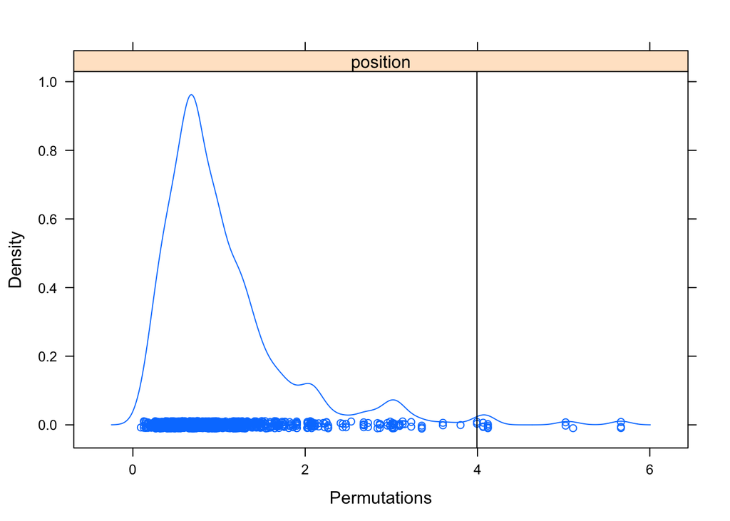

```r
densityplot(permustats(pmv))
```